# Predictive Analytics of Brain Stroke Vulnerability via Lifestyle and Health Factors Analysis

2023-10-24

**Summary Paper**

Exposition and Curation

1. What do we know about this dataset?

The dataset comprises approximately ten distinct features, including gender, age, hypertension, heart disease, marital status, work type, residence type, average glucose level, BMI, and smoking status. The primary target variable under investigation is the presence of a stroke. The dataset encompasses roughly 5000 observations. The target variable, along with two other features, heart disease and hypertension, is binary, with values of either 0 (absent) or 1 (present) to indicate the presence or absence of these conditions.

2. What are the limitations of the dataset?

Firstly, the sample size of approximately 5000 observations is relatively modest, potentially limiting the dataset’s ability to capture the full complexity of factors influencing stroke occurrence. Larger datasets are generally preferred for healthcare-related studies, particularly when studying rare events like strokes.

Additionally, the dataset’s imbalanced target variable, which contains very few instances of strokes compared to non-stroke cases, poses a significant challenge. Class imbalance can hinder the development of accurate predictive models, and addressing this issue is crucial for meaningful results. While the absence of missing values is a positive aspect, it doesn’t entirely alleviate the concerns related to data quality. The dataset might still contain inaccuracies or inconsistencies that could impact the reliability of any analyses or models.

The choice of features in the dataset is another limitation. It’s essential to ensure that all relevant factors influencing stroke occurrence are adequately represented. Furthermore, the categorical variables, like “smoking status” and “work type,” might lack more detailed subcategories, potentially missing important nuances in these variables.

Data bias remains a concern, particularly if the dataset is drawn from specific regions or populations. Such bias can restrict the generalizability of findings and models to broader populations or healthcare contexts. The data collection methods used can introduce bias or limitations, especially if the data primarily originates from a specific type of healthcare facility. This can affect the dataset’s representativeness and relevance to different healthcare settings.

The dataset might not account for all potential confounding factors, such as family history, genetic predisposition, or specific lifestyle variables, which can significantly impact the likelihood of strokes.

3. How was the information gathered?

We got the stroke dataset from a website called Kaggle, but the website does not say how the data was collected. We tried to contact the person who put the data on Kaggle to learn more, but they did not respond to our messages.

**Importing and Summary of the Stroke Data**

```r
summary(stroke)
```

```
##     gender               age         hypertension     heart_disease
##  Length:4981        Min.   : 0.08   Min.   :0.00000   Min.   :0.00000
##  Class :character   1st Qu.:25.00   1st Qu.:0.00000   1st Qu.:0.00000
##  Mode  :character   Median :45.00   Median :0.00000   Median :0.00000
##                     Mean   :43.42   Mean   :0.09617   Mean   :0.05521
##                     3rd Qu.:61.00   3rd Qu.:0.00000   3rd Qu.:0.00000
##                     Max.   :82.00   Max.   :1.00000   Max.   :1.00000
##  ever_married        work_type         Residence_type     avg_glucose_level
##  Length:4981        Length:4981        Length:4981        Min.   : 55.12
##  Class :character   Class :character   Class :character   1st Qu.: 77.23
##  Mode  :character   Mode  :character   Mode  :character   Median : 91.85
##                                                           Mean   :105.94
##                                                           3rd Qu.:113.86
##                                                           Max.   :271.74
##       bmi       smoking_status         stroke
##  Min.   :14.0   Length:4981        Min.   :0.00000
##  1st Qu.:23.7   Class :character   1st Qu.:0.00000
##  Median :28.1   Mode  :character   Median :0.00000
##  Mean   :28.5                      Mean   :0.04979
##  3rd Qu.:32.6                      3rd Qu.:0.00000
##  Max.   :48.9                      Max.   :1.00000
```

We are choosing on the numerical variable age, average glucose level and BMI.

Age: The mean and median do not have a huge difference, therefore less likely to have outliers. Avg_glucose_level: The mean and median have a significant difference and, therefore likely to have outliers. BMI: The mean and median do not have a huge difference, therefore less likely to have outliers.

**Checking for missing values in the data**

There are no missing values in the data

**Changing the work_type children to unemployed**

**Changing the all categorical variable to numeric variables**

```r
#Changing gender to numerical
stroke$gender <- as.numeric(factor(stroke$gender))

#Changing work type to numerical
stroke$work_type <- as.numeric(factor(stroke$work_type))

#Changing the location to numerical
stroke$Residence_type <- as.numeric(factor(stroke$Residence_type))

#Changing the marriage status to numerical
stroke$ever_married <- as.numeric(factor(stroke$ever_married))

#Changing the smoking status to numerical
stroke$smoking_status <- as.numeric(factor(stroke$smoking_status))

final <- stroke
head(final)
```

```
##   gender age hypertension heart_disease ever_married work_type Residence_type
## 1      2  67            0             1            2         2              2
## 2      2  80            0             1            2         2              1
## 3      1  49            0             0            2         2              2
## 4      1  79            1             0            2         3              1
## 5      2  81            0             0            2         2              2
## 6      2  74            1             1            2         2              1
##   avg_glucose_level  bmi smoking_status stroke
## 1            228.69 36.6              1      1
## 2            105.92 32.5              2      1
## 3            171.23 34.4              3      1
## 4            174.12 24.0              2      1
## 5            186.21 29.0              1      1
## 6             70.09 27.4              2      1
```

```r
tail(final)
```

```
##      gender age hypertension heart_disease ever_married work_type
## 4976      2  31            0             0            1         2
## 4977      2  41            0             0            1         2
## 4978      2  40            0             0            2         2
## 4979      1  45            1             0            2         1
## 4980      2  40            0             0            2         2
## 4981      1  80            1             0            2         2
##      Residence_type avg_glucose_level  bmi smoking_status stroke
## 4976              2            215.07 32.7              3      0
## 4977              1             70.15 29.8              1      0
## 4978              2            191.15 31.1              3      0
## 4979              1             95.02 31.8              3      0
## 4980              1             83.94 30.0              3      0
## 4981              2             83.75 29.1              2      0
```

**Introducing the Age Categories**

I have grouped age into four categories such as Children, Student, Adult and Senior Citizen

```r
age_breaks <- c(0, 10, 18, 60, Inf)
age_labels <- c("Children", "Student", "Adult", "Senior Citizen")

# Create a new column with age categories
stroke$Category <- cut(stroke$age, breaks = age_breaks, labels = age_labels)

# Print the data set
print(head(stroke))
```

```
##   gender age hypertension heart_disease ever_married work_type Residence_type
## 1      2  67            0             1            2         2              2
## 2      2  80            0             1            2         2              1
## 3      1  49            0             0            2         2              2
## 4      1  79            1             0            2         3              1
## 5      2  81            0             0            2         2              2
## 6      2  74            1             1            2         2              1
##   avg_glucose_level  bmi smoking_status stroke       Category
## 1            228.69 36.6              1      1 Senior Citizen
## 2            105.92 32.5              2      1 Senior Citizen
## 3            171.23 34.4              3      1          Adult
## 4            174.12 24.0              2      1 Senior Citizen
## 5            186.21 29.0              1      1 Senior Citizen
## 6             70.09 27.4              2      1 Senior Citizen
```

**Finding outliers of BMI and average glucose level in the data**

```r
bmi_outliers <- ezids::outlierKD2(stroke,bmi, rm=TRUE, boxplt=FALSE, histogram=FALSE, qqplt=TRUE)
```

```
## Outliers identified: 43
## Proportion (%) of outliers: 0.9
## Mean of the outliers: 47.41
## Mean without removing outliers: 28.5
## Mean if we remove outliers: 28.33
## Outliers successfully removed
```

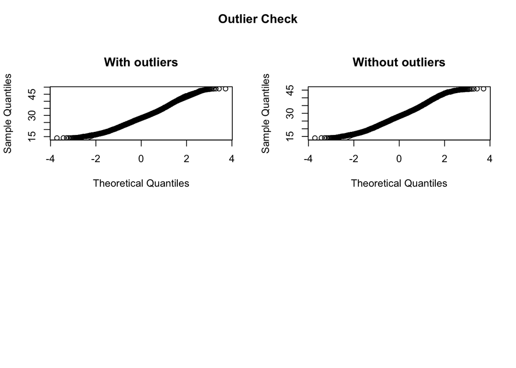

```
## Outliers identified: 602
## Proportion (%) of outliers: 13.7
## Mean of the outliers: 211.41
## Mean without removing outliers: 105.94
## Mean if we remove outliers: 91.44
## Outliers successfully removed
```

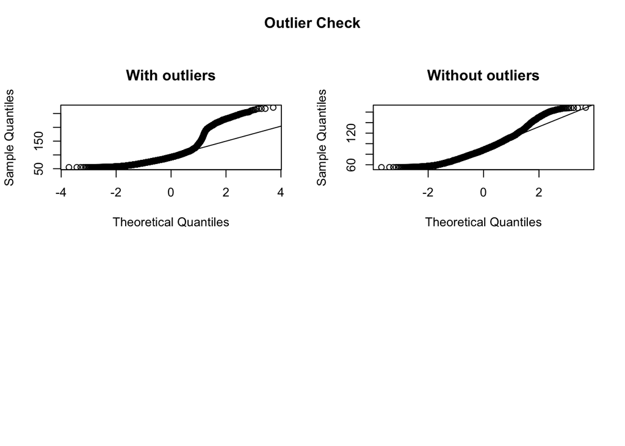

```r
avg_glucose_outliers <- ezids::outlierKD2(stroke,avg_glucose_level, rm=TRUE, boxplt=FALSE, histogram=FALSE, qqplt=TRUE)
```

We have found 43 outliers in BMI and 602 in average glucose level.

**Checking Skewness of Age, BMI and Average Glucose Level**

```r
library(psych)
skew_age <- skew(stroke$age)
print(skew_age)
```

```
## [1] -0.1439145
```

```r
skew_glucose <- skew(stroke$avg_glucose_level)
print(skew_glucose)
```

```
## [1] 1.58657
```

```r
skew_BMI <- skew(stroke$bmi)
print(skew_BMI)
```

```
## [1] 0.3713292
```

The skewness of age indicates a slight leftward skew in the data distribution, with more values concentrated on the right side of the mean, but the distribution is approximately symmetric. A skewness value of average glucose level and BMI indicates a right skewed distribution, with a longer tail on the right side of the mean. This suggests that there are more data points on the left side of the mean.

**Calculating variance and standard deviation**

```r
sd_age <- sd(stroke$age)
print(sd_age)
```

```
## [1] 22.66276
```

```r
sd_glucose <- sd(stroke$avg_glucose_level)
print(sd_glucose)
```

```
## [1] 45.07537
```

```r
sd_BMI <- sd(stroke$bmi)
print(sd_BMI)
```

```
## [1] 6.790464
```

```r
var_age <- var(stroke$age)
print(var_age)
```

```
## [1] 513.6005
```

```r
var_glucose <- var(stroke$avg_glucose_level)
print(var_glucose)
```

```
## [1] 2031.789
```

```r
var_BMI <- var(stroke$bmi)
print(var_BMI)
```

```
## [1] 46.1104
```

The standard deviation value suggests that the data for average glucose levels has a wider spread than that of age and BMI. A higher variance implies that the data points deviate more from their respective means, with glucose displaying a greater spread from the mean in contrast to age and BMI.

**Calculating kurtosis for age, average glucose level and BMI**

```r
library(moments)
kurtosis_age <- kurtosis(stroke$age)
print(kurtosis_age)
```

```
## [1] 2.004955
```

```r
kurtosis_glucose <- kurtosis(stroke$avg_glucose_level)
print(kurtosis_glucose)
```

```
## [1] 4.74971
```

```r
kurtosis_BMI <- kurtosis(stroke$bmi)
print(kurtosis_BMI)
```

```
## [1] 2.860614
```

**Calculation of Mode for age, average glucose level and BMI**

```r
library(DescTools)
mode_age <- Mode(stroke$age)
print(mode_age)
```

```
## [1] 78
## attr(,"freq")
## [1] 102
```

```r
mode_glucose <- Mode(stroke$avg_glucose_level)
print(mode_glucose)
```

```
## [1] 93.88
## attr(,"freq")
## [1] 6
```

```r
mode_BMI <- Mode(stroke$bmi)
print(mode_BMI)
```

```
## [1] 28.7
## attr(,"freq")
## [1] 42
```

**Histogram for distribution for Age**

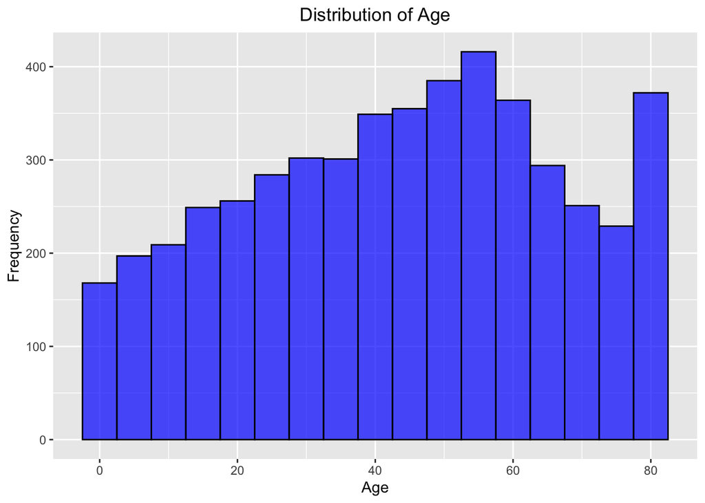

```r
library(ggplot2)
ggplot(stroke, aes(x = age)) +
  geom_histogram(binwidth = 5, fill = "blue", color = "black", alpha = 0.7) +
  ggtitle("Use theme(plot.title = element_text(hjust = 0.5)) to center") +
  theme(plot.title = element_text(hjust = 0.5)) +
  labs(title = "Distribution of Age",
       x = "Age",
       y = "Frequency")
```

The distribution is having thick tail on both the sides.

**Histogram for distribution for Average Glucose level**

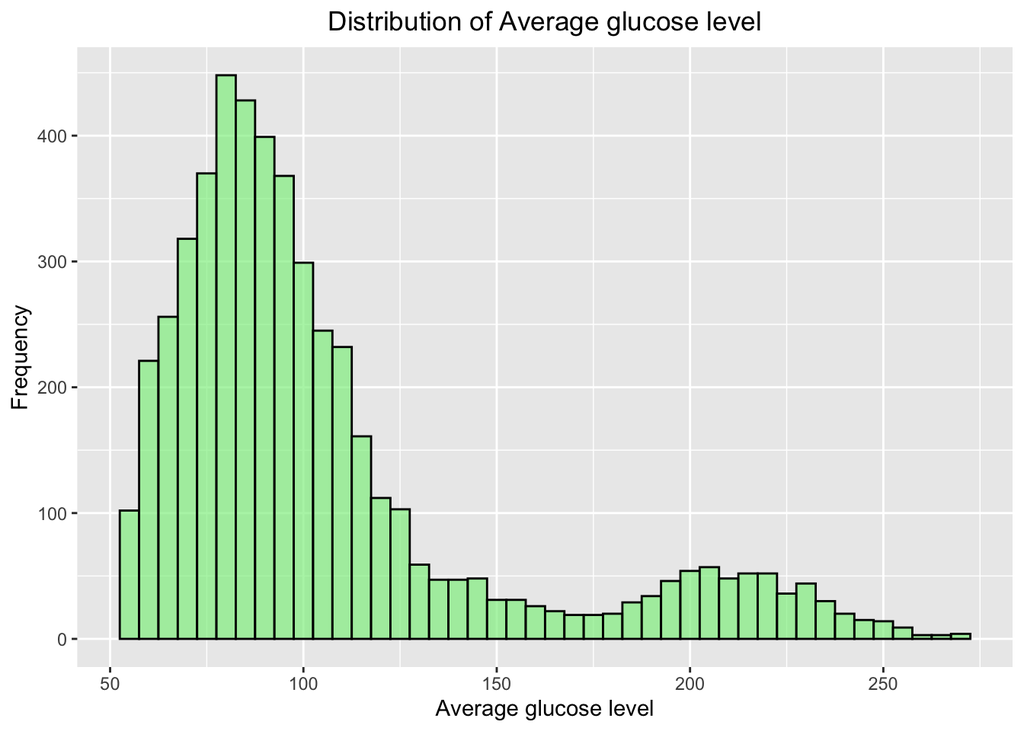

```r
ggplot(stroke, aes(x = avg_glucose_level)) +
  geom_histogram(binwidth = 5, fill = "lightgreen", color = "black", alpha = 0.7) +
  ggtitle("Use theme(plot.title = element_text(hjust = 0.5)) to center") +
  theme(plot.title = element_text(hjust = 0.5)) +
  labs(title = "Distribution of Average glucose level",
       x = "Average glucose level",
       y = "Frequency")
```

The graph is right skewed then the mean is greater than median. The distribution is not symmetrical. Most data points are concentrated on left.

**Distribution of BMI**

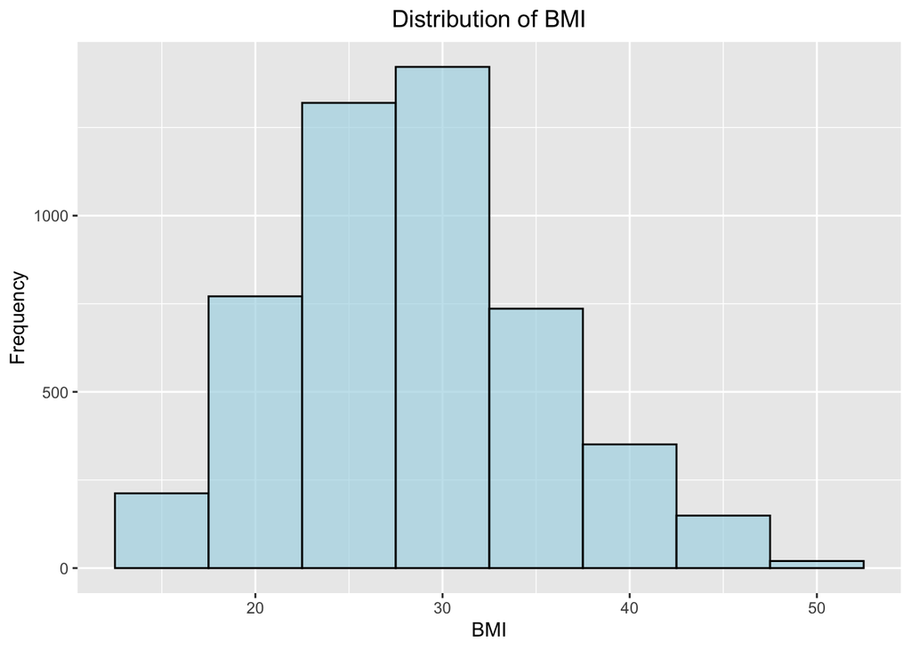

```r
ggplot(stroke, aes(x = bmi)) +
  geom_histogram(binwidth = 5, fill = "lightblue", color = "black", alpha = 0.7) +
  ggtitle("Use theme(plot.title = element_text(hjust = 0.5))") +
  theme(plot.title = element_text(hjust = 0.5)) +
  labs(title = "Distribution of BMI",
       x = "BMI",
       y = "Frequency")
```

The graph is almost normally distributed then the mean and median will almost be equal. The graph is also be symmetrical.

**The effect of average glucose level in hypertension**

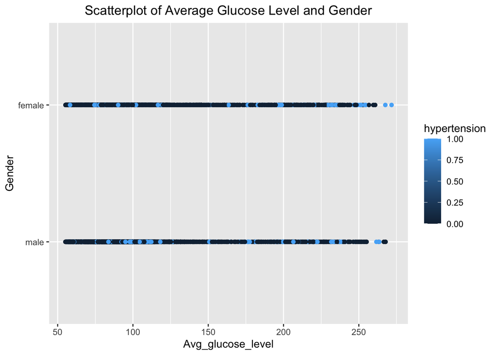

```r
library(ggplot2)
stroke$gender_label <- factor(ifelse(stroke$gender == 1, "male", "female"), levels = c("male", "female"))
ggplot(stroke, aes(y = gender_label, x = avg_glucose_level, color = hypertension)) +
  geom_point() +
  ggtitle("Use theme(plot.title = element_text(hjust = 0.5)) to center") +
  theme(plot.title = element_text(hjust = 0.5)) +
  labs(title = "Scatterplot of Average Glucose Level and Gender",y = "Gender", x = "Avg_glucose_level")
```

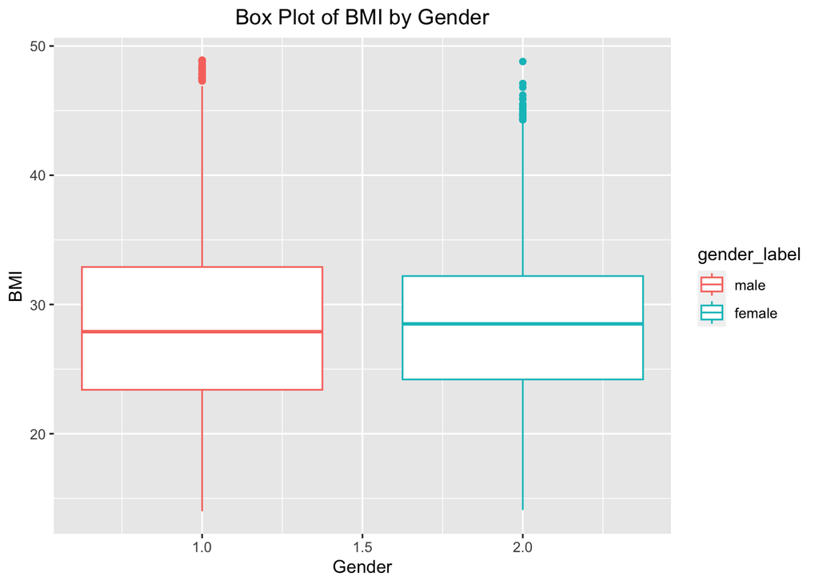

```r
library(ggplot2)
ggplot(stroke, aes(x = gender, y = bmi,color = gender_label)) +
  geom_boxplot() +
  ggtitle("Use theme(plot.title = element_text(hjust = 0.5)) to center") +
  theme(plot.title = element_text(hjust = 0.5)) +
  labs(
    title = "Box Plot of BMI by Gender",
    x = "Gender",
    y = "BMI"
  )
```

From this graph we understand that the average BMI Count of both gender is under 35 approximately

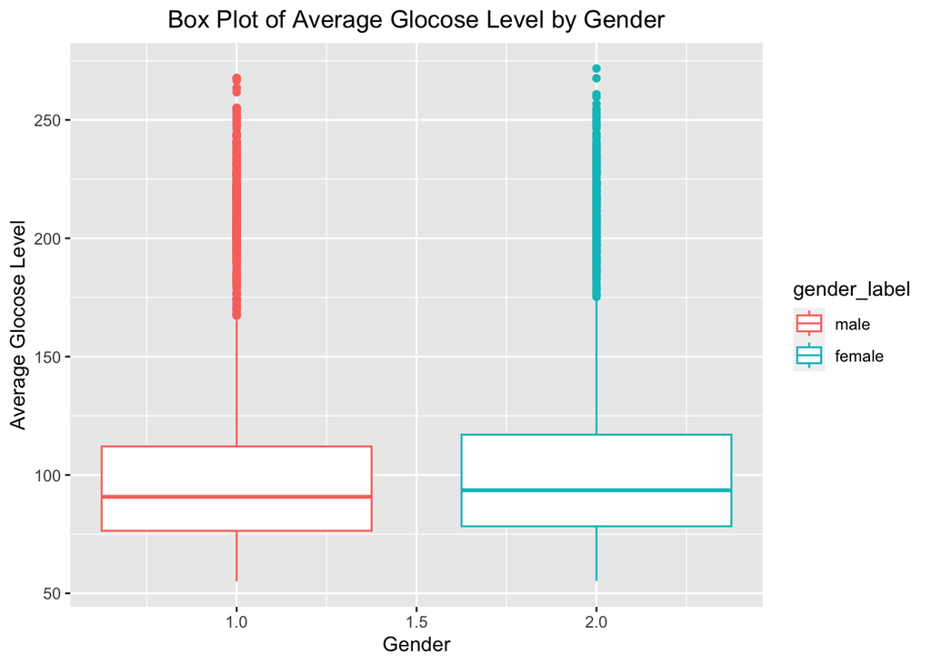

```r
library(ggplot2)
ggplot(stroke, aes(x = gender, y = avg_glucose_level,color = gender_label)) +
  geom_boxplot() +
  ggtitle("Use theme(plot.title = element_text(hjust = 0.5)) to center") +
  theme(plot.title = element_text(hjust = 0.5)) +
  labs(
    title = "Box Plot of Average Glocose Level by Gender",
    x = "Gender",
    y = "Average Glocose Level"
  )
```

From this graph we understand that the average glucose level is right skewed.

Null Hypothesis(H0): Age and stroke variables are independent.

Alternative Hypothesis(Ha): Age and stroke are not independent.

```r
Contingency_Table_Age <- table(stroke$Category , stroke$stroke)
Chi_Square_Test_Age_BS <- chisq.test(Contingency_Table_Age)
print(Chi_Square_Test_Age_BS$p.value)
```

```
## [1] 7.506175e-62
```

The p-value for this test is <0.05 (Standard Significane level), therefore we reject Null Hypothesis. Hence we can conclude that Age and stroke are not independent. Age group significantly matters in chances of having a brain stroke.

**Which category in age has highest number of Brain Strokes**

```r
print(Contingency_Table_Age)
```

```
##
##                     0    1
##   Children        492    1
##   Student         386    1
##   Adult          2738   69
##   Senior Citizen 1117  177
```

```r
brain_stroke_yes <- subset(stroke,stroke == 1)
brain_stroke_no <- subset(stroke,stroke == 0)
```

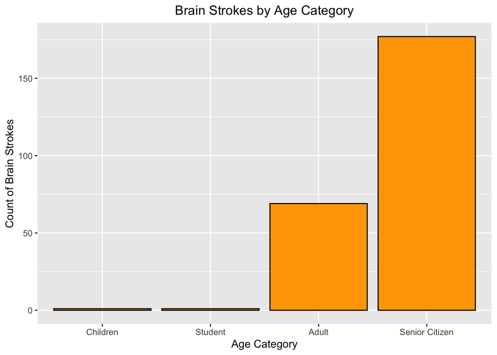

```r
ggplot(data = brain_stroke_yes, aes(x = `Category`, fill = `Category`)) +
  geom_bar(position = "stack",col="black", fill="Orange") +
  labs(title = "Brain Strokes by Age Category",
       x = "Age Category",
       y = "Count of Brain Strokes") +
  theme(plot.title = element_text(hjust = 0.5))
```

```r
library(dplyr)
```

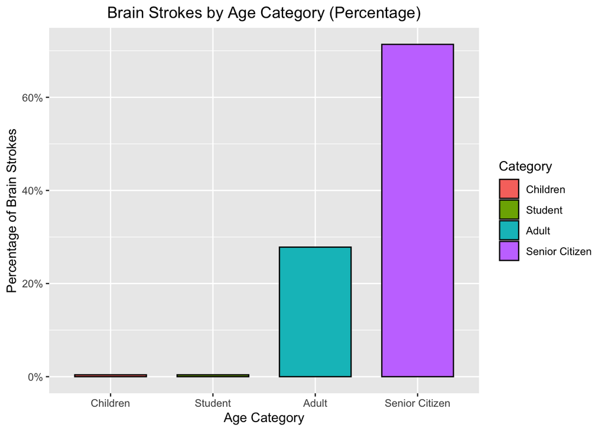

```r
# Calculate the total number of cases
total_cases <- nrow(brain_stroke_yes)

# Calculate the percentage of brain strokes for each age category
brain_stroke_yes_percentage <- brain_stroke_yes %>%
  group_by(Category) %>%
  summarise(Percentage = (n() / total_cases) * 100)

# Create the bar plot with percentages
ggplot(data = brain_stroke_yes_percentage, aes(x = `Category`, y = Percentage, fill = `Category`)) +
  geom_bar(stat = "identity", col = "black", width = 0.7, position = "stack") +
  labs(title = "Brain Strokes by Age Category (Percentage)",
       x = "Age Category",
       y = "Percentage of Brain Strokes") +
  scale_y_continuous(labels = scales::percent_format(scale = 1)) +  # Format y-axis as percentage
  theme(plot.title = element_text(hjust = 0.5))
```

The “Senior Citizen” age group exhibits the highest likelihood of experiencing a brain stroke, accounting for nearly 70% of cases

Null Hypothesis(H0): Worktype and stroke variables are independent.

Alternative Hypothesis(Ha): Worktype and stroke are not independent.

```r
Contingency_Table_worktype <- table(stroke$work_type , stroke$stroke)
Chi_Square_Test_worktype_BS <- chisq.test(Contingency_Table_worktype)
print(Chi_Square_Test_worktype_BS$p.value)
```

```
## [1] 2.312446e-10
```

The p-value for this test is <0.05 (Standard Significane level), therefore we reject Null Hypothesis. Hence we can conclude that worktype and stroke are not independent. Worktype significantly matters in chances of having a brain stroke.

**Which category in worktype has highest number of Brain Strokes***

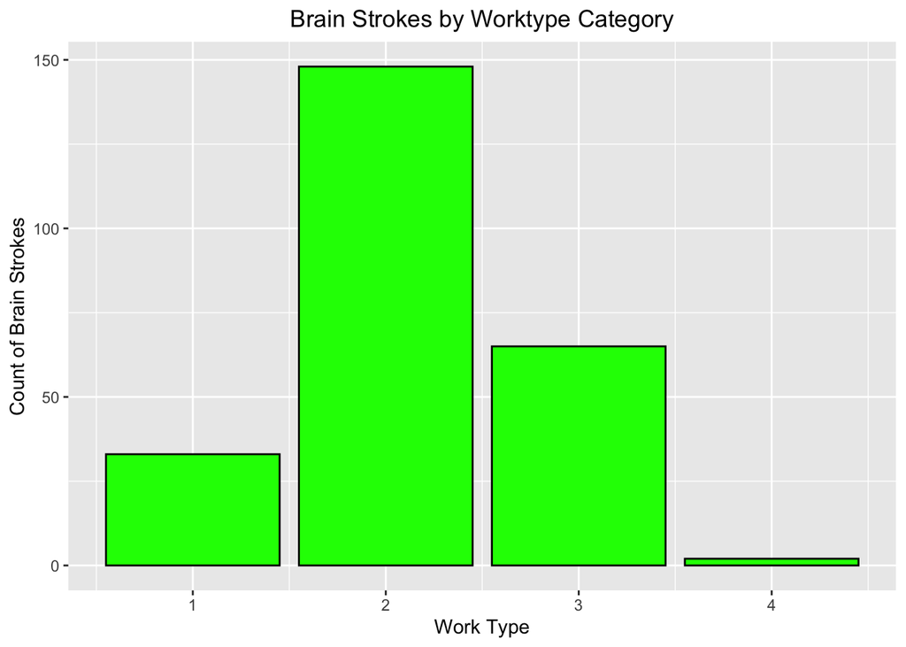

```r
ggplot(data = brain_stroke_yes, aes(x = `work_type`, fill = `work_type`)) +
  geom_bar(position = "stack",col="black", fill="Green",show.legend = TRUE) +
  labs(title = "Brain Strokes by Worktype Category",
       x = "Work Type",
       y = "Count of Brain Strokes") +
  scale_fill_manual(values = c("1" = "blue", "2" = "green", "3" = "red", "4" = "purple"),
                    labels = c("Government Job", "Private", "Self Employed", "Children")) +
  theme(plot.title = element_text(hjust = 0.5))
```

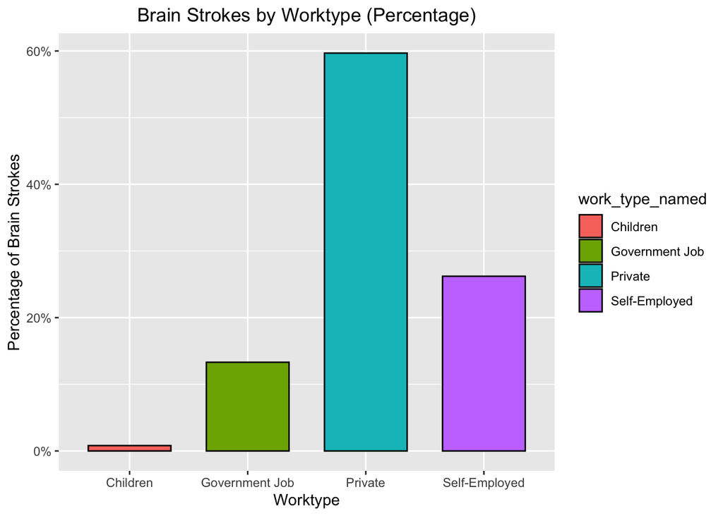

```r
brain_stroke_yes <- brain_stroke_yes %>%
  mutate(work_type_named = case_when(
    work_type == 1 ~ "Government Job",
    work_type == 2 ~ "Private",
    work_type == 3 ~ "Self-Employed",
    work_type == 4 ~ "Children"
  ))


# Calculate the percentage of brain strokes for each age category
brain_stroke_yes_percentage <- brain_stroke_yes %>%
  group_by(work_type_named) %>%
  summarise(Percentage = (n() / total_cases) * 100)

# Create the bar plot with percentages
ggplot(data = brain_stroke_yes_percentage, aes(x = `work_type_named`, y = Percentage, fill = `work_type_named`)) +
  geom_bar(stat = "identity", col = "black", width = 0.7, position = "stack") +
  labs(title = "Brain Strokes by Worktype (Percentage)",
       x = "Worktype",
       y = "Percentage of Brain Strokes") +
  scale_y_continuous(labels = scales::percent_format(scale = 1)) +  # Format y-axis as percentage
  theme(plot.title = element_text(hjust = 0.5))
```

The highest number of Brain strokes is for the Private working people.

**Does brain stroke depend on gender type?**

Null Hypothesis(H0): Gender and stroke variables are independent.

Alternative Hypothesis(Ha): Gender and stroke are not independent.

```r
Contingency_Table_Gender <- table(stroke$gender , stroke$stroke)
Chi_Square_Test_Gender_BS <- chisq.test(Contingency_Table_Gender)
print(Chi_Square_Test_Gender_BS$p.value)
```

```
## [1] 0.5755279
```

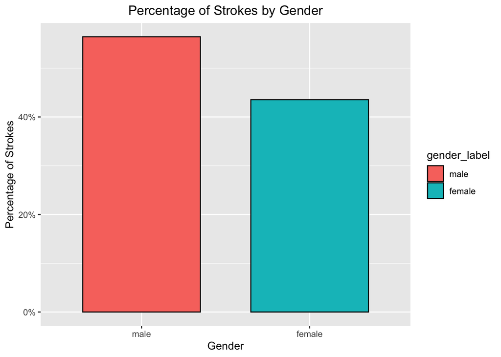

```r
# Calculate the percentage of brain strokes for each gender category
brain_stroke_yes_percentage <- brain_stroke_yes %>%
  group_by(gender_label) %>%
  summarise(Percentage = (n() / total_cases) * 100)

# Create the bar plot with percentages on the y-axis
ggplot(data = brain_stroke_yes_percentage, aes(x = gender_label, y = Percentage, fill = gender_label)) +
  geom_bar(stat = "identity", col = "black", width = 0.7, position = "stack") +
  labs(title = "Percentage of Strokes by Gender",
       x = "Gender",
       y = "Percentage of Strokes") +
  scale_y_continuous(labels = scales::percent_format(scale = 1)) +  # Format y-axis as percentage
  theme(plot.title = element_text(hjust = 0.5))
```

p-value is greater than 0.05 (Standard Significance level) and therefore we accept Null Hypothesis and so we can conclude that brain stroke doesn’t depend on gender type.

**Does brain stroke depend on Location type?**

Null Hypothesis(H0): Location and stroke variables are independent.

Alternative Hypothesis(Ha): Location and stroke are not independent.

```r
Contingency_Table_Location <- table(stroke$Residence_type , stroke$stroke)
Chi_Square_Test_Location_BS <- chisq.test(Contingency_Table_Location)
print(Chi_Square_Test_Location_BS$p.value)
```

```
## [1] 0.271793
```

p-value is greater than 0.05 (Standard Significance level) and therefore we accept Null Hypothesis and so we can conclude that brain stroke doesn’t depend on Location of residence.

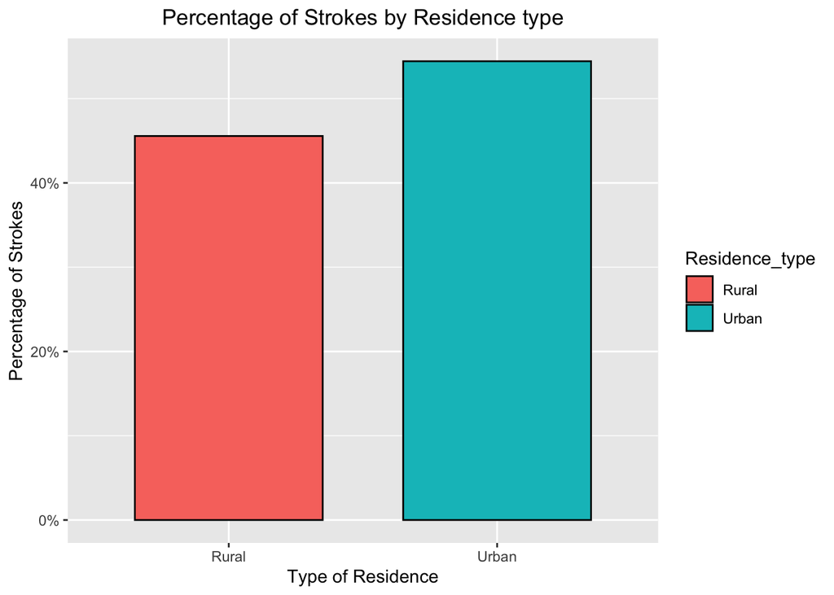

```r
brain_stroke_yes <- brain_stroke_yes %>%
  mutate(Residence_type = case_when(
    Residence_type == 1 ~ "Rural",
    Residence_type == 2 ~ "Urban"
  ))

# Calculate the percentage of brain strokes for each location category
brain_stroke_yes_percentage <- brain_stroke_yes %>%
  group_by(Residence_type) %>%
  summarise(Percentage = (n() / total_cases) * 100)

# Create the bar plot with percentages on the y-axis
ggplot(data = brain_stroke_yes_percentage, aes(x = Residence_type, y = Percentage, fill = Residence_type)) +
  geom_bar(stat = "identity", col = "black", width = 0.7, position = "stack") +
  labs(title = "Percentage of Strokes by Residence type",
       x = "Type of Residence",
       y = "Percentage of Strokes") +
  scale_y_continuous(labels = scales::percent_format(scale = 1)) +  # Format y-axis as percentage
  theme(plot.title = element_text(hjust = 0.5))
```

**Does brain stroke depend on ever-married?**

```r
# Chi-squared test of ever_married and stroke
contable_marr_str <- table(stroke$ever_married, stroke$stroke)
chitest_marr_str <- chisq.test(contable_marr_str)
chitest_marr_str
```

```
##
##  Pearson's Chi-squared test with Yates' continuity correction
##
## data:  contable_marr_str
## X-squared = 57.481, df = 1, p-value = 3.412e-14
```

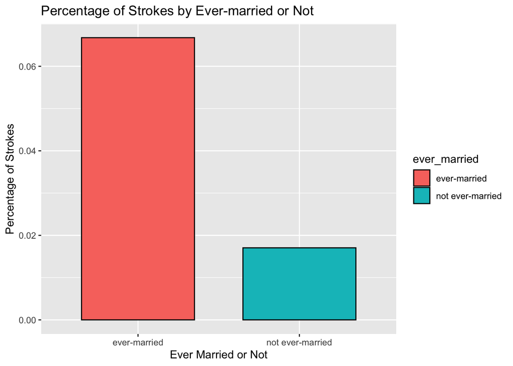

```r
# changing the labels of "ever_married"
brain_stroke_yes$ever_married <- factor(brain_stroke_yes$ever_married, levels = c("1", "2"), labels = c("unmarried(with stroke)", "married(with stroke)"))
brain_stroke_no$ever_married <- factor(brain_stroke_no$ever_married, levels = c("1", "2"), labels = c("unmarried(without stroke)", "married(without stroke)"))

married <- subset(stroke, ever_married==2)
unmarried <- subset(stroke, ever_married==1)
total_cases_married <- nrow(married)
total_cases_notmarried <- nrow(unmarried)

# Calculating the percentage of ever-married in group with stroke and without stroke respectively
married_str_percentage = nrow(subset(married, married$stroke==1)) / total_cases_married
unmarried_str_percentage = nrow(subset(unmarried, unmarried$stroke==1)) / total_cases_notmarried
Percentageofstr_married <- c(married_str_percentage, unmarried_str_percentage)
ever_married <- c("ever-married", "not ever-married")
married_strpercentage <- data.frame(Percentageofstr_married, ever_married)

# Creating the bar plot with percentage on the y-axis
ggplot(married_strpercentage, aes(x=ever_married, y=Percentageofstr_married, fill=ever_married)) +
  geom_bar(stat = "identity", col = "black", width = 0.7) +
  labs(x = "Ever Married or Not", y = "Percentage of Strokes", title = "Percentage of Strokes by Ever-married or Not")
```

```r
contable_marr_age <- table(stroke$ever_married, stroke$Category)
chitest_marr_age <- chisq.test(contable_marr_age)
chitest_marr_age
```

```
##
##  Pearson's Chi-squared test
##
## data:  contable_marr_age
## X-squared = 2183, df = 3, p-value < 2.2e-16
```

**How do hypertension and heart disease influence brain stroke?**

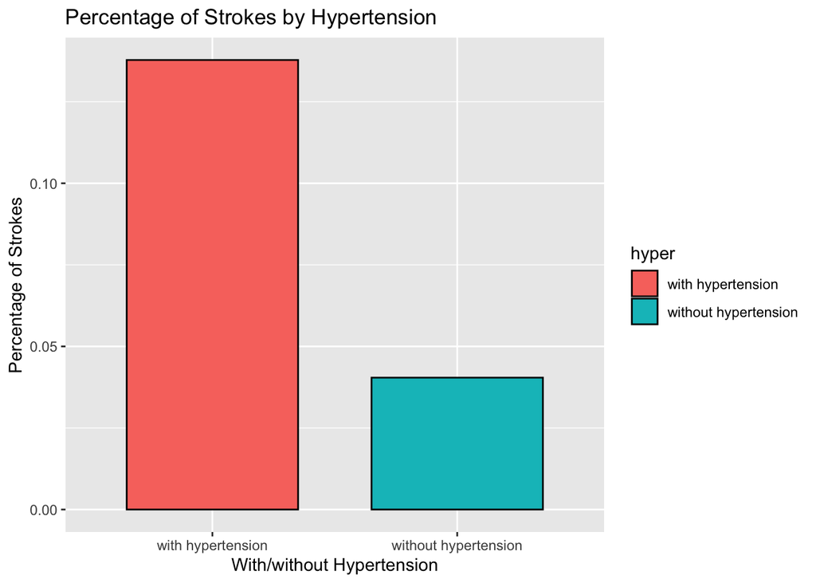

```r
# changing the labels of "hypertension"
# brain_stroke_yes$hypertension <- factor(brain_stroke_yes$hypertension, levels = c("0", "1"), labels = c("no hypertension", "have hypertension"))
# brain_stroke_no$hypertension <- factor(brain_stroke_no$hypertension, levels = c("0", "1"), labels = c("no hypertension", "have hypertension"))

with_hyper <- subset(stroke, hypertension==1)
without_hyper <- subset(stroke, hypertension==0)
total_cases_withhyper <- nrow(with_hyper)
total_cases_withouthyper <- nrow(without_hyper)

# total_cases_yes <- nrow(brain_stroke_yes)
# total_cases_no <- nrow(brain_stroke_no)

# Calculating the percentage of hypertension in group with stroke and without stroke respectively
withhyper_str_percentage <- nrow(subset(with_hyper, with_hyper$stroke==1)) / total_cases_withhyper
withouthyper_str_percentage = nrow(subset(without_hyper, without_hyper$stroke==1)) / total_cases_withouthyper
Percentageofstr_hyper <- c(withhyper_str_percentage, withouthyper_str_percentage)
hyper <- c("with hypertension", "without hypertension")
hyper_strpercentage <- data.frame(Percentageofstr_hyper, hyper)

ggplot(hyper_strpercentage, aes(x=hyper, y=Percentageofstr_hyper, fill=hyper)) +
  geom_bar(stat = "identity", col = "black", width = 0.7) +
  labs(x = "With/without Hypertension", y = "Percentage of Strokes", title = "Percentage of Strokes by Hypertension")
```

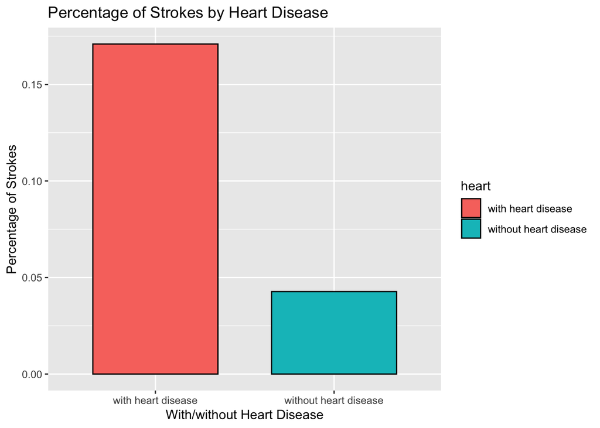

```r
# changing the labels of "heart_disease"
# brain_stroke_yes$heart_disease <- factor(brain_stroke_yes$heart_disease, levels = c("0", "1"), labels = c("no heart disease", "have heart disease"))
# brain_stroke_no$heart_disease <- factor(brain_stroke_no$heart_disease, levels = c("0", "1"), labels = c("no heart disease", "have heart disease"))

with_heart <- subset(stroke, heart_disease==1)
without_heart <- subset(stroke, heart_disease==0)
total_cases_withheart <- nrow(with_heart)
total_cases_withoutheart <- nrow(without_heart)

# Calculating the percentage of heart disease in group with stroke and without stroke respectively
withheart_strpercentage <- nrow(subset(with_heart, with_heart$stroke==1)) / total_cases_withheart
withoutheart_strpercentage = nrow(subset(without_heart, without_heart$stroke==1)) / total_cases_withoutheart
Percentageofstr_heart <- c(withheart_strpercentage, withoutheart_strpercentage)
heart <- c("with heart disease", "without heart disease")
heart_strpercentage <- data.frame(Percentageofstr_heart, heart)

ggplot(heart_strpercentage, aes(x=heart, y=Percentageofstr_heart, fill=heart)) +
  geom_bar(stat = "identity", col = "black", width = 0.7) +
  labs(x = "With/without Heart Disease", y = "Percentage of Strokes", title = "Percentage of Strokes by Heart Disease")
```

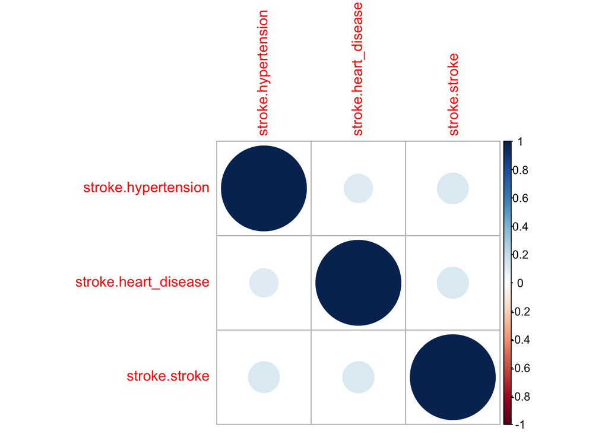

```r
library("corrplot")
hyp_heart_str_cor <- cor(data.frame(stroke$hypertension, stroke$heart_disease, stroke$stroke))
corrplot(hyp_heart_str_cor)
```

```r
contable_hyp_str <- table(stroke$hypertension, stroke$stroke)
chitest_hyp_str <- chisq.test(contable_hyp_str)
chitest_hyp_str
```

```
##
##  Pearson's Chi-squared test with Yates' continuity correction
##
## data:  contable_hyp_str
## X-squared = 84.698, df = 1, p-value < 2.2e-16
```

```r
contable_heart_str <- table(stroke$heart_disease, stroke$stroke)
chitest_heart_str <- chisq.test(contable_heart_str)
chitest_heart_str
```

```
##
##  Pearson's Chi-squared test with Yates' continuity correction
##
## data:  contable_heart_str
## X-squared = 87.566, df = 1, p-value < 2.2e-16
```

```r
contable_hyp_heart <- table(stroke$hypertension, stroke$heart_disease)
chitest_hyp_heart <- chisq.test(contable_hyp_heart)
chitest_hyp_heart
```

```
##
##  Pearson's Chi-squared test with Yates' continuity correction
##
## data:  contable_hyp_heart
## X-squared = 60.8, df = 1, p-value = 6.317e-15
```

**What are modifiable and non-modifiable risk factors for stroke in healthy people?**  
We can take features like avg_glucose_level, bmi and smoking_status.

```r
#get responsible features from main dataset
healthy_features <- stroke[,8:11]
healthy_features$smoking_status <- replace(healthy_features$smoking_status, healthy_features$smoking_status==4, 3)
```

For smoking status and stroke, we use chi square goodness of fit test as they are two categorical variables.  
$H_0:$ smoking and stroke are independent features  
$H_1:$ smoking and stroke are not independent

```r
# contingency table for smoking_status and stroke
contingency_table_smoking <- table(healthy_features$smoking_status, healthy_features$stroke)
print(contingency_table_smoking)
```

```
##
##        0    1
##   1  797   70
##   2 1749   89
##   3 2187   89
```

```r
chi_smoke_status = chisq.test(contingency_table_smoking)
print(chi_smoke_status)
```

```
##
##  Pearson's Chi-squared test
##
## data:  contingency_table_smoking
## X-squared = 23.119, df = 2, p-value = 9.546e-06
```

Normality Check for Body Mass Index

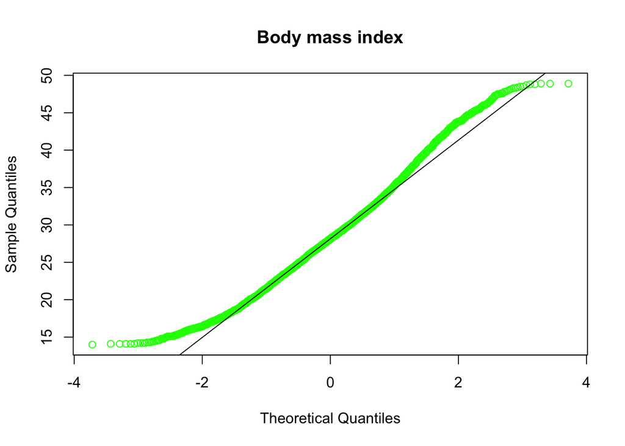

```r
qqnorm(healthy_features$bmi, main="Body mass index", col='green')
qqline(healthy_features$bmi)
```

As p-value for the test is low, we reject null hypothesis. Now we plot bar for smoking_status vs stroke.

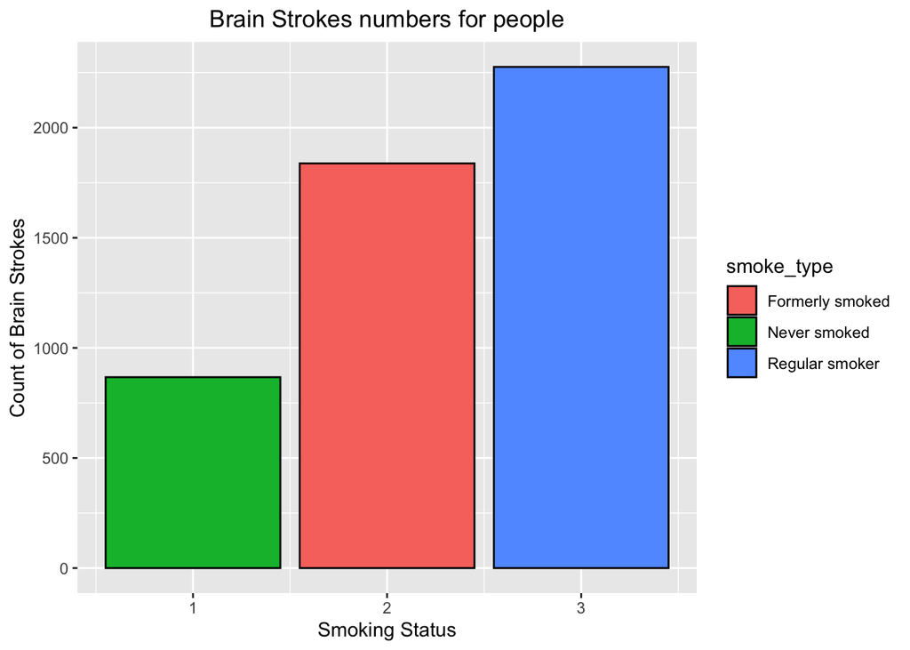

```r
# add smoking categories
healthy_features <- healthy_features %>%
  mutate(smoke_type = case_when(
    smoking_status == 1 ~ "Never smoked",
    smoking_status == 2 ~ "Formerly smoked",
    smoking_status == 3 ~ "Regular smoker"
  ))

# create barplot
ggplot(data = healthy_features, aes(x = `smoking_status`, fill = smoke_type)) +
  geom_bar(position = "stack",col="black") +
  labs(title = "Brain Strokes numbers for people",
       x = "Smoking Status",
       y = "Count of Brain Strokes") +
  theme(plot.title = element_text(hjust = 0.5))
```

For BMI and stroke, we do a 2-sample test considering them as numerical features.  
$H_0$: bmi and stroke are independent  
$H_1$: bmi and stroke are not independent

```r
# two sample t-test
two_sample_bmi <- t.test(healthy_features$bmi, healthy_features$stroke)
two_sample_bmi
```

```
##
##  Welch Two Sample t-test
##
## data:  healthy_features$bmi and healthy_features$stroke
## t = 295.52, df = 4990.2, p-value < 2.2e-16
## alternative hypothesis: true difference in means is not equal to 0
## 95 percent confidence interval:
##  28.25966 28.63710
## sample estimates:
##  mean of x  mean of y
## 28.4981731  0.0497892
```

As p-value for the test is low, we reject null hypothesis. Now we plot bar for BMI vs stroke.

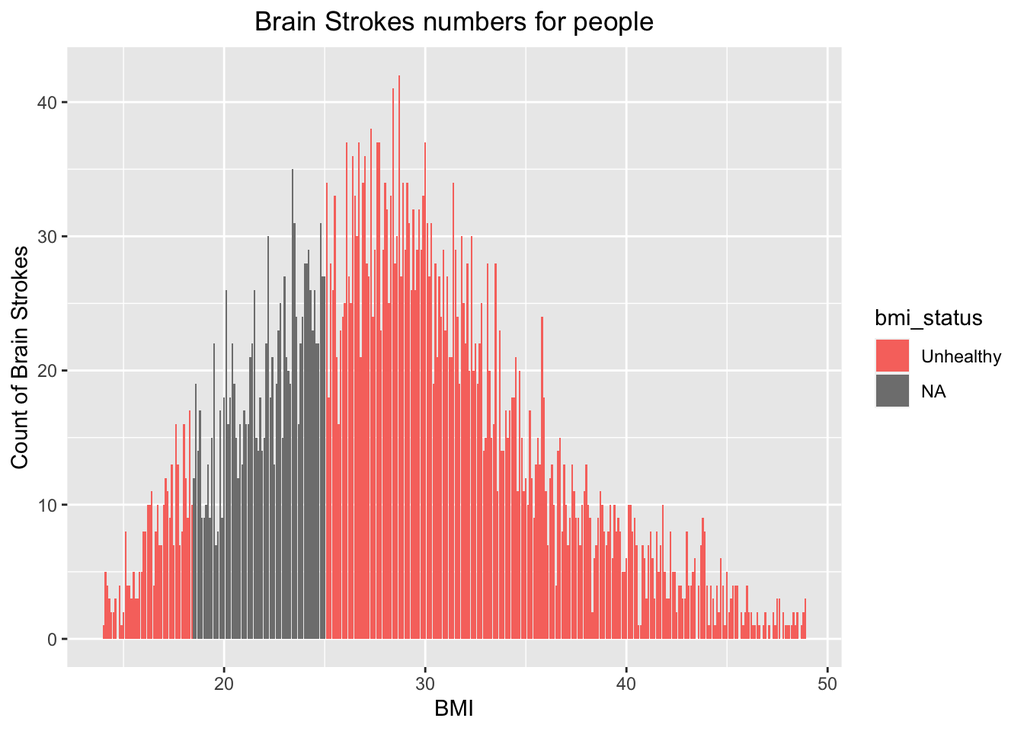

```r
# add bmi_status column
healthy_features <- healthy_features %>%
  mutate(bmi_status = case_when(
    bmi > 25  ~ "Unhealthy",
    bmi < 18.5 ~ "Unhealthy",
  ))
# create barplot between bmi_status and stroke
ggplot(data = healthy_features, aes(x = `bmi`, fill = `bmi_status`)) +
  geom_bar(position = "stack") +
  labs(title = "Brain Strokes numbers for people",
       x = "BMI",
       y = "Count of Brain Strokes") +
  theme(plot.title = element_text(hjust = 0.5))
```

Normality check for Average Glucose Level

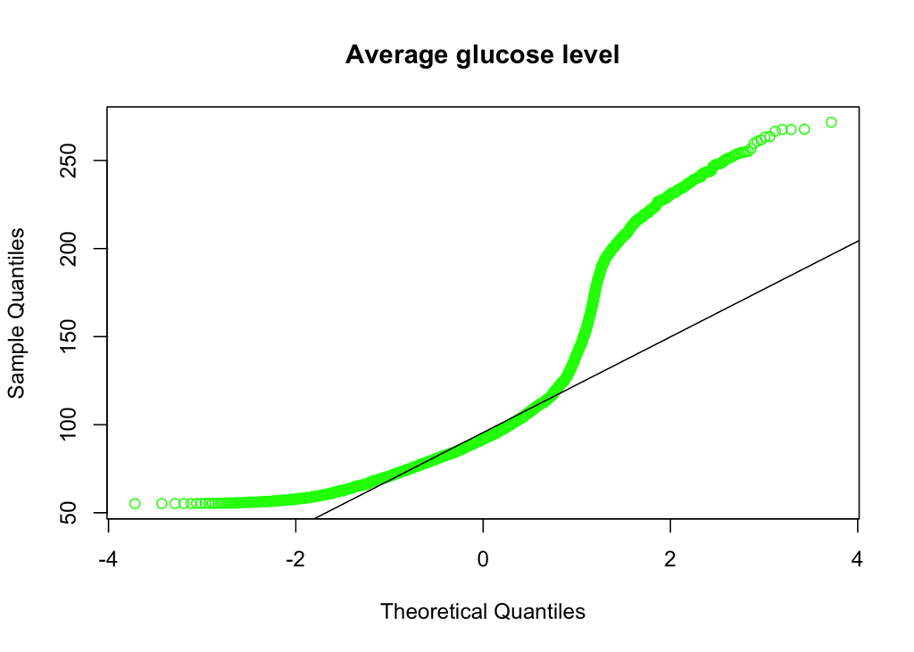

```r
qqnorm(healthy_features$avg_glucose_level, main="Average glucose level", col='green')
qqline(healthy_features$avg_glucose_level)
```

Distribution for average glucose level is not normally distributed.

For avg glucose level and stroke we use 2-sample t-test considering themas numercial variables.  
$H_0$: agl and stroke are independent  
$H_1$: agl and stroke are not independent

```r
# 2 sample t-test
two_sample_agl <- t.test(healthy_features$avg_glucose_level, healthy_features$stroke)
print(two_sample_agl)
```

```
##
##  Welch Two Sample t-test
##
## data:  healthy_features$avg_glucose_level and healthy_features$stroke
## t = 165.8, df = 4980.2, p-value < 2.2e-16
## alternative hypothesis: true difference in means is not equal to 0
## 95 percent confidence interval:
##  104.6417 107.1459
## sample estimates:
##   mean of x   mean of y
## 105.9435615   0.0497892
```

Plot histogram for average glucose level and stroke

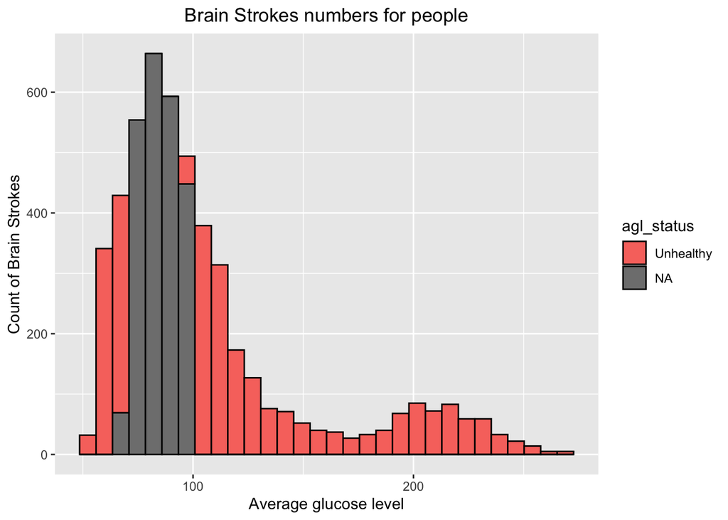

```r
# add column for agl_status based on avg_glucose_level
healthy_features <- healthy_features %>%
  mutate(agl_status = case_when(
    avg_glucose_level > 100  ~ "Unhealthy",
    avg_glucose_level < 70 ~ "Unhealthy",
  ))

# create plot and fill by agl_status
ggplot(data = healthy_features, aes(x = `avg_glucose_level`, fill = `agl_status`)) +
  geom_histogram(position = "stack",col="black") +
  labs(title = "Brain Strokes numbers for people",
       x = "Average glucose level",
       y = "Count of Brain Strokes") +
  theme(plot.title = element_text(hjust = 0.5))
```

Now combining all features together and test healthy people with stroke. As two are categorical, we use chi square test.  
$H_0$: Health and stroke are independent  
$H_1$: Health and stroke are not independent

```r
# Create a column for health_status
healthy_features<- transform(healthy_features, health_status=ifelse(avg_glucose_level<100 & avg_glucose_level>70 & bmi<25 & bmi>18.5, 1,0))

healthy_table <- table(healthy_features$health_status, healthy_features$stroke)
chigoodness = chisq.test(healthy_table)
print(chigoodness$p.value)
```

```
## [1] 0.02138168
```

Due to low p-value, we reject null hypothesis.

Barplot between health feature and stroke

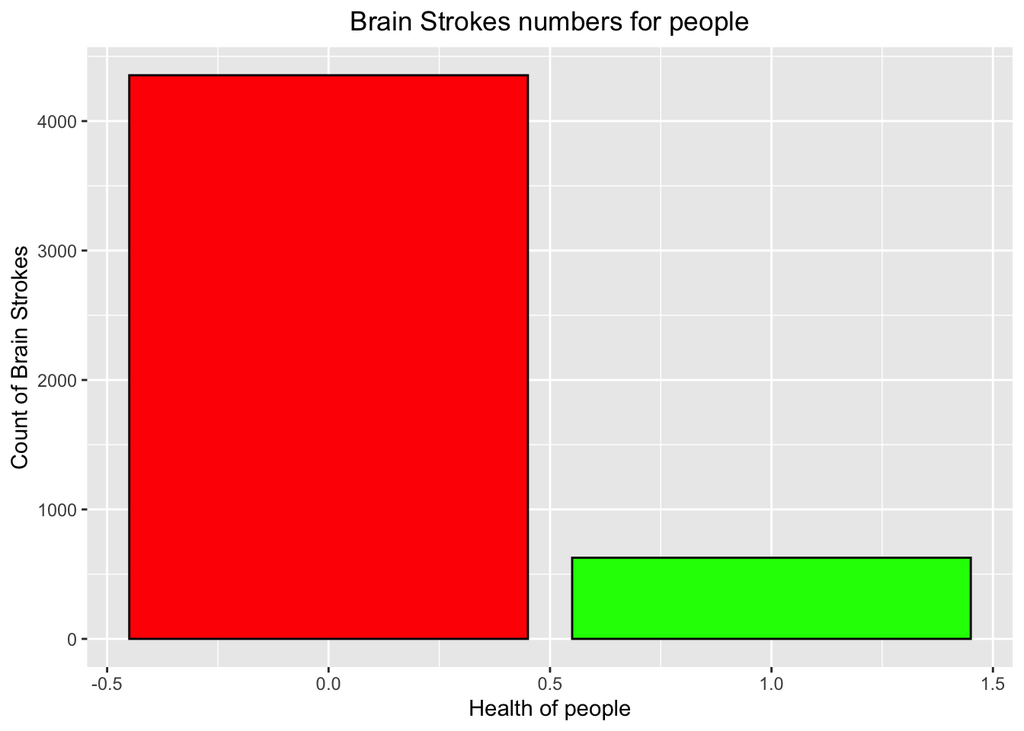

```r
#Create plot for health_status vs stroke
ggplot(data = healthy_features, aes(x = `health_status`, fill='health_status')) +
  geom_bar(position = "stack",col="black", fill=c("red","green")) +
  labs(title = "Brain Strokes numbers for people",
       x = "Health of people",
       y = "Count of Brain Strokes") +
  theme(plot.title = element_text(hjust = 0.5))
```

**Q. What married life and gender are associated with an increased risk of stroke?**  
We combine two columns to form another column. As two are categorical, we use chi square test.  
$H_0:$ The variables are independent  
$H_1:$ The variables are not independent

```r
# Create a dataframe with factors responsible for married_living
df_married_living <- stroke[c('gender', 'ever_married', 'stroke')]

df_married_living <- df_married_living %>%
  mutate(married_living = case_when(
    gender==2 & ever_married==2 ~ 'Married male',
    gender==2 & ever_married==1 ~ 'Unmarried male',
    gender==1 & ever_married==2 ~ 'Married female',
    gender==1 & ever_married==1 ~ 'Unmarried female'
  ))
# contingency status for married_living and stroke
con_table <- table(df_married_living$married_living, df_married_living$stroke)
print(con_table)
```

```
##
##                       0    1
##   Married female   1829  119
##   Married male     1232  100
##   Unmarried female  938   21
##   Unmarried male    734    8
```

```r
chi_test <- chisq.test(con_table)
print(chi_test)
```

```
##
##  Pearson's Chi-squared test
##
## data:  con_table
## X-squared = 62.891, df = 3, p-value = 1.417e-13
```

```r
table(df_married_living$gender,df_married_living$ever_married)
```

```
##
##        1    2
##   1  959 1948
##   2  742 1332
```

Due to low p-value, we reject $H_0$.

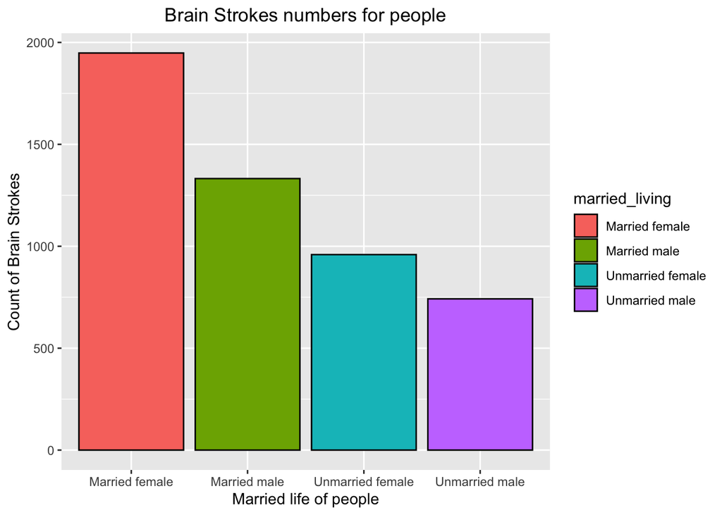

```r
# Create plot between married_living and stroke
ggplot(data = df_married_living, aes(x = `married_living`, fill=married_living)) +
  geom_bar(position = "stack",col="black") +
  labs(title = "Brain Strokes numbers for people",
       x = "Married life of people",
       y = "Count of Brain Strokes") +
  theme(plot.title = element_text(hjust = 0.5))
```